# EDA

We get the following summary statistics:

|  | percent_of_classes_under_20 | student_faculty_ratio | alumni_giving_rate | private |
| --- | --- | --- | --- | --- |
| count | 48.000000 | 48.000000 | 48.000000 | 48.000000 |
| mean | 55.729167 | 11.541667 | 29.270833 | 0.687500 |
| std | 13.193712 | 4.850788 | 13.441346 | 0.468417 |
| min | 29.000000 | 3.000000 | 7.000000 | 0.000000 |
| 25% | 44.750000 | 8.000000 | 18.750000 | 0.000000 |
| 50% | 59.500000 | 10.500000 | 29.000000 | 1.000000 |
| 75% | 66.250000 | 13.500000 | 38.500000 | 1.000000 |
| max | 77.000000 | 23.000000 | 67.000000 | 1.000000 |

- We observed that there are 33 private universities (with value 1 under private) & 15 public universities.

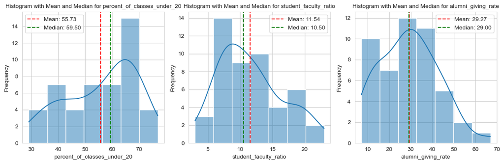

But do we have any outliers?

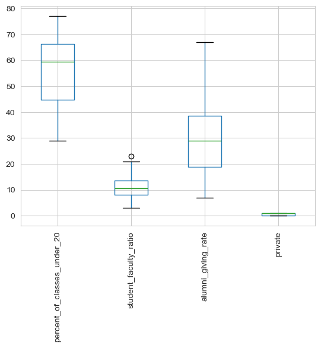

```
school                         0
percent_of_classes_under_20    0
student_faculty_ratio          1
alumni_giving_rate             0
private                        0
dtype: int64
```

Using the Inter-Quantile Range method, we got just one outlier in "student_faculty_ratio" (X₂), and it appears in the following row(row number 33, as our rows started with row number 0)

|  | school | percent_of_classes_under_20 | student_faculty_ratio | alumni_giving_rate | private |
| --- | --- | --- | --- | --- | --- |
| 32 | U. of Florida | 31 | 23 | 19 | 0 |

So the value of 23 in X₂ appears to be an outlier as per IQR. This is to be noted that the second highest value is 21 for University of Texas at Austin at row number 41(40 in the dataframe). As the value doesn't appear to be highly skewed and we have a dataset of only 48 samples, let us go ahead without ommiting the value and go ahead with the regression analysis. Further among the histograms for the continuous variables, we see that:

- percent_of_classes_under_20 has a left skewed distribution
- student_faculty_ratio has a right skewed distribution
- alumni_giving_rate has a symmetric distribution as mean and median are approcimately equal but graph looks right skewed.

If we want to deduce the co-relation among all our variable, we get to see the following plot.

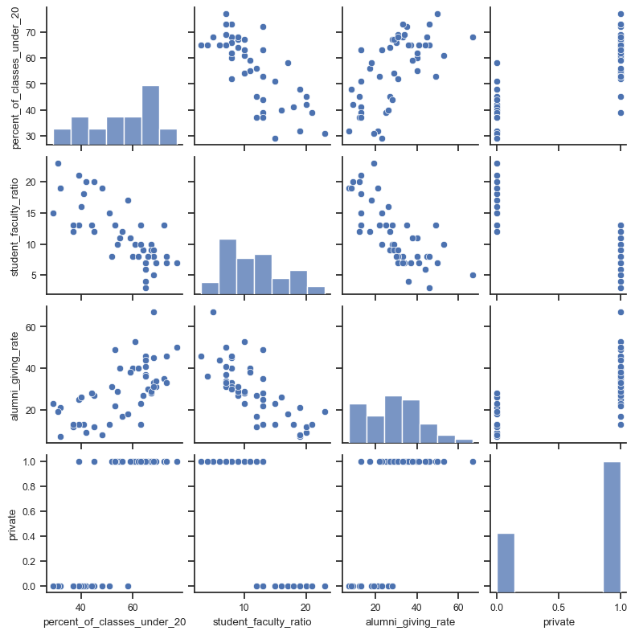

|  | percent_of_classes_under_20 | student_faculty_ratio | alumni_giving_rate | private |
| --- | --- | --- | --- | --- |
| percent_of_classes_under_20 | 1.000000 | -0.785559 | 0.645650 | 0.791611 |
| student_faculty_ratio | -0.785559 | 1.000000 | -0.742397 | -0.813489 |
| alumni_giving_rate | 0.645650 | -0.742397 | 1.000000 | 0.689588 |
| private | 0.791611 | -0.813489 | 0.689588 | 1.000000 |